# customer-segmentation

Sofyan Adi Saputra

2024-01-29

# 1. DATA PREPARATION

Dataset yang digunakan : https://www.kaggle.com/datasets/sofyanadi/customer-segmentation

```r
#Load Dataset
#path/lokasi dataset
df <- read.csv("C:/Users/sofyan/Documents/R/Mini Project/customer-segmentation/Datasets/customer_segments.csv", sep = "\t")

#Vector untuk Menyimpan Nama Field
field_yang_digunakan <- df[c("Jenis.Kelamin", "Umur", "Profesi")]
field_yang_digunakan
```

```
##    Jenis.Kelamin Umur          Profesi
## 1           Pria   58       Wiraswasta
## 2         Wanita   14          Pelajar
## 3           Pria   48     Professional
## 4           Pria   53     Professional
## 5         Wanita   41       Wiraswasta
## 6         Wanita   24     Professional
## 7           Pria   64       Wiraswasta
## 8           Pria   52     Professional
## 9         Wanita   29     Professional
## 10          Pria   33     Professional
## 11        Wanita   50     Professional
## 12        Wanita   49     Professional
## 13        Wanita   64       Wiraswasta
## 14          Pria   60       Wiraswasta
```

[output cut: 36 more lines]

```r
#Konversi Data dengan data.matrix
pelanggan_matrix <- data.matrix(df[c("Jenis.Kelamin", "Profesi", "Tipe.Residen")])
pelanggan_matrix
```

```
##       Jenis.Kelamin Profesi Tipe.Residen
##  [1,]             1       5            2
##  [2,]             2       3            1
##  [3,]             1       4            1
##  [4,]             1       4            1
##  [5,]             2       5            1
##  [6,]             2       4            1
##  [7,]             1       5            2
##  [8,]             1       4            1
##  [9,]             2       4            2
## [10,]             1       4            1
## [11,]             2       4            2
## [12,]             2       4            2
## [13,]             2       5            1
## [14,]             1       5            1
```

[output cut: 36 more lines]

```r
#Penggabungan data pelanggan dan data pelanggan_matriks
pelanggan <- data.frame(df, pelanggan_matrix)
pelanggan
```

```
##    Customer_ID        Nama.Pelanggan Jenis.Kelamin Umur          Profesi
## 1     CUST-001          Budi Anggara          Pria   58       Wiraswasta
## 2     CUST-002      Shirley Ratuwati        Wanita   14          Pelajar
## 3     CUST-003          Agus Cahyono          Pria   48     Professional
## 4     CUST-004      Antonius Winarta          Pria   53     Professional
## 5     CUST-005   Ibu Sri Wahyuni, IR        Wanita   41       Wiraswasta
## 6     CUST-006       Rosalina Kurnia        Wanita   24     Professional
## 7     CUST-007         Cahyono, Agus          Pria   64       Wiraswasta
## 8     CUST-008        Danang Santosa          Pria   52     Professional
## 9     CUST-009 Elisabeth Suryadinata        Wanita   29     Professional
## 10    CUST-010        Mario Setiawan          Pria   33     Professional
## 11    CUST-011        Maria Suryawan        Wanita   50     Professional
## 12    CUST-012       Erliana Widjaja        Wanita   49     Professional
## 13    CUST-013          Cahaya Putri        Wanita   64       Wiraswasta
## 14    CUST-014        Mario Setiawan          Pria   60       Wiraswasta
```

[output cut: 87 more lines]

```r
#Menormalisasikan Nilai Belanja
pelanggan$NilaiBelanjaSetahun <- pelanggan$NilaiBelanjaSetahun / 1000000
pelanggan
```

```
##    Customer_ID        Nama.Pelanggan Jenis.Kelamin Umur          Profesi
## 1     CUST-001          Budi Anggara          Pria   58       Wiraswasta
## 2     CUST-002      Shirley Ratuwati        Wanita   14          Pelajar
## 3     CUST-003          Agus Cahyono          Pria   48     Professional
## 4     CUST-004      Antonius Winarta          Pria   53     Professional
## 5     CUST-005   Ibu Sri Wahyuni, IR        Wanita   41       Wiraswasta
## 6     CUST-006       Rosalina Kurnia        Wanita   24     Professional
## 7     CUST-007         Cahyono, Agus          Pria   64       Wiraswasta
## 8     CUST-008        Danang Santosa          Pria   52     Professional
## 9     CUST-009 Elisabeth Suryadinata        Wanita   29     Professional
## 10    CUST-010        Mario Setiawan          Pria   33     Professional
## 11    CUST-011        Maria Suryawan        Wanita   50     Professional
## 12    CUST-012       Erliana Widjaja        Wanita   49     Professional
## 13    CUST-013          Cahaya Putri        Wanita   64       Wiraswasta
## 14    CUST-014        Mario Setiawan          Pria   60       Wiraswasta
```

[output cut: 87 more lines]

```r
#Membuat Data Master
Profesi <- unique(pelanggan[c("Profesi","Profesi.1")])
Jenis.Kelamin <- unique(pelanggan[c("Jenis.Kelamin","Jenis.Kelamin.1")])
Tipe.Residen <- unique(pelanggan[c("Tipe.Residen","Tipe.Residen.1")])
pelanggan[c("Profesi","Profesi.1", "Jenis.Kelamin" ,"Jenis.Kelamin.1","Tipe.Residen", "Tipe.Residen.1")]
```

```
##             Profesi Profesi.1 Jenis.Kelamin Jenis.Kelamin.1 Tipe.Residen
## 1        Wiraswasta         5          Pria               1       Sector
## 2           Pelajar         3        Wanita               2      Cluster
## 3      Professional         4          Pria               1      Cluster
## 4      Professional         4          Pria               1      Cluster
## 5        Wiraswasta         5        Wanita               2      Cluster
## 6      Professional         4        Wanita               2      Cluster
## 7        Wiraswasta         5          Pria               1       Sector
## 8      Professional         4          Pria               1      Cluster
## 9      Professional         4        Wanita               2       Sector
## 10     Professional         4          Pria               1      Cluster
## 11     Professional         4        Wanita               2       Sector
## 12     Professional         4        Wanita               2       Sector
## 13       Wiraswasta         5        Wanita               2      Cluster
## 14       Wiraswasta         5          Pria               1      Cluster
```

[output cut: 87 more lines]

Terlihat, teks “Pria” diubah menjadi angka 1, “Wanita” diubah menjadi angka 2, “Wiraswasta” pada kolom profesi diubah menjadi angka 5, “Sector” pada tipe residen menjadi 2 dan seterusnya.

Akhiran .1 ditambahkan karena di variable pelanggan sudah ada nama kolom yang sama. Sebagai contoh kolom “Jenis.Kelamin” yang terdapat pada pelanggan_matrix sudah ada juga di variable pelanggan. Jadi ketika digabungkan, R akan menambahkan akhiran .1 untuk kolom “Jenis.Kelamin” yang terdapat di pelanggan_matrix.

Terlihat data telah diringkas dengan teks kategori beserta pasangan numeriknya.

# 2. CLUSTERING DAN K-MEANS ALGORITHM

```r
#Fungsi K-Means
field_yang_digunakan = c("Jenis.Kelamin.1", "Umur", "Profesi.1", "Tipe.Residen.1","NilaiBelanjaSetahun")

#Bagian K-Means
set.seed(1)
#fungsi kmeans untuk membentuk 5 cluster dengan 25 skenario random dan simpan ke dalam variable segmentasi
segmentasi <- kmeans(x=pelanggan[field_yang_digunakan][c("Jenis.Kelamin.1", "Umur", "Profesi.1", "Tipe.Residen.1","NilaiBelanjaSetahun")], centers=5, nstart=25)
#tampilkan hasil k-means
segmentasi
```

```
## K-means clustering with 5 clusters of sizes 12, 10, 5, 14, 9
##
## Cluster means:
##   Jenis.Kelamin.1     Umur Profesi.1 Tipe.Residen.1 NilaiBelanjaSetahun
## 1            1.75 31.58333  3.916667       1.250000            7.330958
## 2            1.70 52.50000  3.800000       1.300000            6.018321
## 3            1.40 61.80000  4.200000       1.400000            8.696132
## 4            2.00 20.07143  3.571429       1.357143            5.901089
## 5            2.00 42.33333  4.000000       1.555556            8.804791
##
## Clustering vector:
##  [1] 3 4 2 2 5 4 3 2 1 1 2 2 3 3 4 1 1 3 1 4 5 2 1 5 1 2 1 5 2 5 4 5 4 4 5 1 4 5
## [39] 4 4 4 1 1 4 4 4 2 5 1 2
##
## Within cluster sum of squares by cluster:
## [1] 174.85164 108.49735  58.21123 316.73367 171.67372
##  (between_SS / total_SS =  92.4 %)
##
## Available components:
##
## [1] "cluster"      "centers"      "totss"        "withinss"     "tot.withinss"
## [6] "betweenss"    "size"         "iter"         "ifault"
```

```r
#Analisa Hasil Clustering Vector - Penggabungan hasil cluster
segmentasi$cluster
```

```
##  [1] 3 4 2 2 5 4 3 2 1 1 2 2 3 3 4 1 1 3 1 4 5 2 1 5 1 2 1 5 2 5 4 5 4 4 5 1 4 5
## [39] 4 4 4 1 1 4 4 4 2 5 1 2
```

```r
pelanggan$cluster <- segmentasi$cluster
str(pelanggan)
```

```
## 'data.frame':    50 obs. of  11 variables:
##  $ Customer_ID        : chr  "CUST-001" "CUST-002" "CUST-003" "CUST-004" ...
##  $ Nama.Pelanggan     : chr  "Budi Anggara" "Shirley Ratuwati" "Agus Cahyono" "Antonius Winarta" ...
##  $ Jenis.Kelamin      : chr  "Pria" "Wanita" "Pria" "Pria" ...
##  $ Umur               : int  58 14 48 53 41 24 64 52 29 33 ...
##  $ Profesi            : chr  "Wiraswasta" "Pelajar" "Professional" "Professional" ...
##  $ Tipe.Residen       : chr  "Sector" "Cluster" "Cluster" "Cluster" ...
##  $ NilaiBelanjaSetahun: num  9.5 2.72 5.29 5.2 10.62 ...
##  $ Jenis.Kelamin.1    : int  1 2 1 1 2 2 1 1 2 1 ...
##  $ Profesi.1          : int  5 3 4 4 5 4 5 4 4 4 ...
##  $ Tipe.Residen.1     : int  2 1 1 1 1 1 2 1 2 1 ...
##  $ cluster            : int  3 4 2 2 5 4 3 2 1 1 ...
```

```r
#Analisa Hasil Cluster Size
#List data pada Cluster
which(pelanggan$cluster == 1)
```

```
##  [1]  9 10 16 17 19 23 25 27 36 42 43 49
```

```r
which(pelanggan$cluster == 2)
```

```
##  [1]  3  4  8 11 12 22 26 29 47 50
```

```r
which(pelanggan$cluster == 3)
```

```
## [1]  1  7 13 14 18
```

```r
which(pelanggan$cluster == 4)
```

```
##  [1]  2  6 15 20 31 33 34 37 39 40 41 44 45 46
```

```r
which(pelanggan$cluster == 5)
```

```
## [1]  5 21 24 28 30 32 35 38 48
```

```r
#Jumlah data pada Cluster
length(which(pelanggan$cluster == 1))
```

```
## [1] 12
```

```r
length(which(pelanggan$cluster == 2))
```

```
## [1] 10
```

```r
length(which(pelanggan$cluster == 3))
```

```
## [1] 5
```

```r
length(which(pelanggan$cluster == 4))
```

```
## [1] 14
```

```r
length(which(pelanggan$cluster == 5))
```

```
## [1] 9
```

```r
#Melihat Data pada Cluster ke-N
#Melihat data cluster ke 3-5
pelanggan[which(pelanggan$cluster == 3),]
```

```
##    Customer_ID Nama.Pelanggan Jenis.Kelamin Umur          Profesi Tipe.Residen
## 1     CUST-001   Budi Anggara          Pria   58       Wiraswasta       Sector
## 7     CUST-007  Cahyono, Agus          Pria   64       Wiraswasta       Sector
## 13    CUST-013   Cahaya Putri        Wanita   64       Wiraswasta      Cluster
## 14    CUST-014 Mario Setiawan          Pria   60       Wiraswasta      Cluster
## 18    CUST-018    Nelly Halim        Wanita   63 Ibu Rumah Tangga      Cluster
##    NilaiBelanjaSetahun Jenis.Kelamin.1 Profesi.1 Tipe.Residen.1 cluster
## 1             9.497927               1         5              2       3
## 7             9.837260               1         5              2       3
## 13            9.333168               2         5              1       3
## 14            9.471615               1         5              1       3
## 18            5.340690               2         1              1       3
```

```r
pelanggan[which(pelanggan$cluster == 4),]
```

```
##    Customer_ID   Nama.Pelanggan Jenis.Kelamin Umur          Profesi
## 2     CUST-002 Shirley Ratuwati        Wanita   14          Pelajar
## 6     CUST-006  Rosalina Kurnia        Wanita   24     Professional
## 15    CUST-015 Shirley Ratuwati        Wanita   20       Wiraswasta
## 20    CUST-020   Irene Novianto        Wanita   16          Pelajar
## 31    CUST-031    Eviana Handry        Wanita   19        Mahasiswa
## 33    CUST-033  Cecilia Kusnadi        Wanita   19        Mahasiswa
## 34    CUST-034   Deasy Arisandi        Wanita   21       Wiraswasta
## 37    CUST-037 Felicia Tandiono        Wanita   25     Professional
## 39    CUST-039     Gina Hidayat        Wanita   20     Professional
## 40    CUST-040   Irene Darmawan        Wanita   14          Pelajar
## 41    CUST-041 Shinta Aritonang        Wanita   24 Ibu Rumah Tangga
## 44    CUST-044             Anna        Wanita   18       Wiraswasta
## 45    CUST-045   Rismawati Juni        Wanita   22     Professional
## 46    CUST-046     Elfira Surya        Wanita   25       Wiraswasta
```

[output cut: 30 more lines]

```r
pelanggan[which(pelanggan$cluster == 5),]
```

```
##    Customer_ID      Nama.Pelanggan Jenis.Kelamin Umur          Profesi
## 5     CUST-005 Ibu Sri Wahyuni, IR        Wanita   41       Wiraswasta
## 21    CUST-021    Lestari Fabianto        Wanita   38       Wiraswasta
## 24    CUST-024       Putri Ginting        Wanita   39       Wiraswasta
## 28    CUST-028       Adeline Huang        Wanita   40 Ibu Rumah Tangga
## 30    CUST-030      Rosita Saragih        Wanita   46 Ibu Rumah Tangga
## 32    CUST-032     Chintya Winarni        Wanita   47       Wiraswasta
## 35    CUST-035             Ida Ayu        Wanita   39     Professional
## 38    CUST-038        Agatha Salim        Wanita   46       Wiraswasta
## 48    CUST-048    Maria Hutagalung        Wanita   45       Wiraswasta
##    Tipe.Residen NilaiBelanjaSetahun Jenis.Kelamin.1 Profesi.1 Tipe.Residen.1
## 5       Cluster           10.615206               2         5              1
## 21      Cluster            9.222070               2         5              1
## 24      Cluster           10.259572               2         5              1
## 28      Cluster            6.631680               2         1              1
## 30       Sector            5.020976               2         1              2
## 32       Sector           10.663179               2         5              2
## 35       Sector            5.962575               2         4              2
## 38       Sector           10.477127               2         5              2
## 48       Sector           10.390732               2         5              2
##    cluster
## 5        5
## 21       5
## 24       5
## 28       5
## 30       5
## 32       5
## 35       5
## 38       5
## 48       5
```

```r
#Analisa Hasil Cluster Means
segmentasi$centers
```

```
##   Jenis.Kelamin.1     Umur Profesi.1 Tipe.Residen.1 NilaiBelanjaSetahun
## 1            1.75 31.58333  3.916667       1.250000            7.330958
## 2            1.70 52.50000  3.800000       1.300000            6.018321
## 3            1.40 61.80000  4.200000       1.400000            8.696132
## 4            2.00 20.07143  3.571429       1.357143            5.901089
## 5            2.00 42.33333  4.000000       1.555556            8.804791
```

```r
#Analisa Hasil Sum of Squares
#Membandingkan dengan 2 cluster kmeans, masing-masing 2 dan 5
set.seed(1)
kmeans(x=pelanggan[field_yang_digunakan], centers=2, nstart=25)
```

```
## K-means clustering with 2 clusters of sizes 23, 27
##
## Cluster means:
##   Jenis.Kelamin.1     Umur Profesi.1 Tipe.Residen.1 NilaiBelanjaSetahun
## 1        1.739130 51.17391  3.913043       1.434783            7.551518
## 2        1.888889 25.85185  3.777778       1.296296            6.659586
##
## Clustering vector:
##  [1] 1 2 1 1 1 2 1 1 2 2 1 1 1 1 2 2 2 1 2 2 2 1 2 1 2 1 2 1 1 1 2 1 2 2 1 2 2 1
## [39] 2 2 2 2 2 2 2 2 1 1 2 1
##
## Within cluster sum of squares by cluster:
## [1] 1492.481 1524.081
##  (between_SS / total_SS =  72.6 %)
##
## Available components:
##
## [1] "cluster"      "centers"      "totss"        "withinss"     "tot.withinss"
## [6] "betweenss"    "size"         "iter"         "ifault"
```

```r
set.seed(1)
kmeans(x=pelanggan[field_yang_digunakan], centers=5, nstart=25)
```

```
## K-means clustering with 5 clusters of sizes 12, 10, 5, 14, 9
##
## Cluster means:
##   Jenis.Kelamin.1     Umur Profesi.1 Tipe.Residen.1 NilaiBelanjaSetahun
## 1            1.75 31.58333  3.916667       1.250000            7.330958
## 2            1.70 52.50000  3.800000       1.300000            6.018321
## 3            1.40 61.80000  4.200000       1.400000            8.696132
## 4            2.00 20.07143  3.571429       1.357143            5.901089
## 5            2.00 42.33333  4.000000       1.555556            8.804791
##
## Clustering vector:
##  [1] 3 4 2 2 5 4 3 2 1 1 2 2 3 3 4 1 1 3 1 4 5 2 1 5 1 2 1 5 2 5 4 5 4 4 5 1 4 5
## [39] 4 4 4 1 1 4 4 4 2 5 1 2
##
## Within cluster sum of squares by cluster:
## [1] 174.85164 108.49735  58.21123 316.73367 171.67372
##  (between_SS / total_SS =  92.4 %)
##
## Available components:
##
## [1] "cluster"      "centers"      "totss"        "withinss"     "tot.withinss"
## [6] "betweenss"    "size"         "iter"         "ifault"
```

```r
#Available Components
segmentasi$withinss
```

```
## [1] 174.85164 108.49735  58.21123 316.73367 171.67372
```

```r
segmentasi$cluster
```

```
##  [1] 3 4 2 2 5 4 3 2 1 1 2 2 3 3 4 1 1 3 1 4 5 2 1 5 1 2 1 5 2 5 4 5 4 4 5 1 4 5
## [39] 4 4 4 1 1 4 4 4 2 5 1 2
```

```r
segmentasi$tot.withinss
```

```
## [1] 829.9676
```

Hasil ini dapat dibagi dalam lima bagian, dengan penjelasan sebagai berikut:

1. Ukuran / Jumlah titik data pada tiap cluster
2. Nilai rata-rata (centroid) dari tiap cluster
3. Pembagian cluster dari tiap elemen data berdasarkan posisisnya
4. Jumlah jarak kuadrat dari tiap titik ke centroidnya
5. Komponen informasi lain yang terkandung di dalam objek ini

K-means telah membagi dataset pelanggan dengan 5 cluster dengan jumlah total 50 data, yang juga merupakan jumlah data total pelanggan., dimana:

1. Cluster ke-1 memiliki 12 data
2. Cluster ke-2 memiliki 10 data
3. Cluster ke-3 memiliki 5 data
4. Cluster ke-4 memiliki 14 data
5. Cluster ke-5 memiliki 9 data

Cluster means adalah hasil nilai rata-rata atau titik sentral (centroid) dari seluruh titik tiap cluster. Pada tabel diatas:

- Kolom pertama yang berisi angka 1 sampai dengan 5 adalah mewakili nomor cluster.
- Kolom Kelamin.1 menunjukkan nilai rata-rata dari data jenis kelamin yang telah dikonversi menjadi numerik, dengan angka 1 mewakili Pria dan angka 2 mewakili wanita.

# 3. DATA VISUALIZATION

```r
#install package
install.packages("ggplot2")
#import library
library(ggplot2)

#Simulasi Jumlah Cluster dan SS
set.seed(1)
sse <- sapply(1:10,
              function(param_k){
                kmeans(pelanggan[field_yang_digunakan], param_k, nstart=25)$tot.withinss
              })
sse
```

```
##  [1] 10990.9740  3016.5612  1550.8725  1064.4187   829.9676   625.1462
##  [7]   508.1568   431.6977   374.1095   325.7982
```

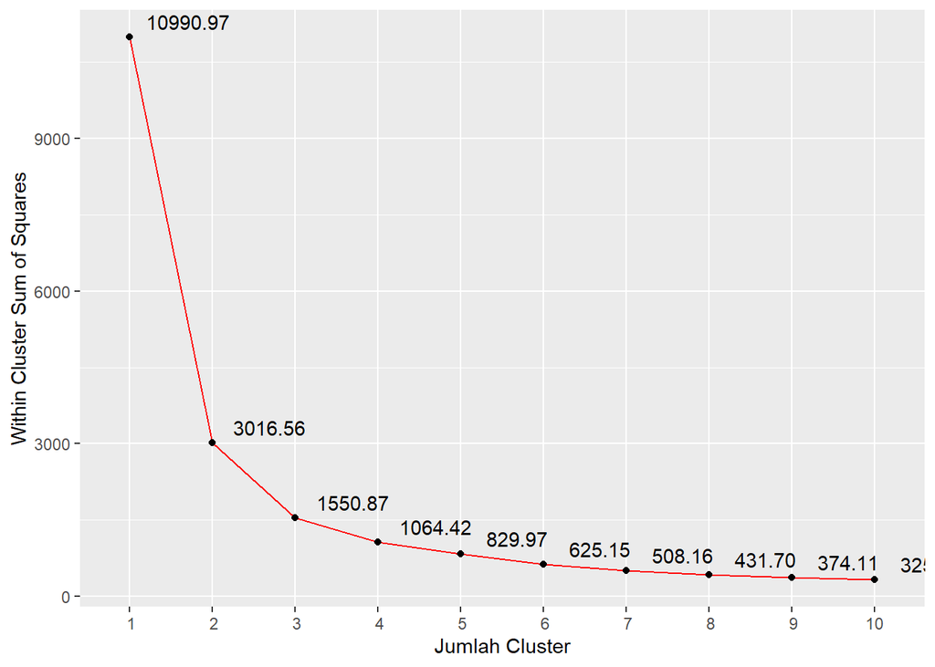

```r
#Grafik Elbow Effect
jumlah_cluster_max <- 10
ssdata = data.frame(cluster=c(1:jumlah_cluster_max),sse)
ggplot(ssdata, aes(x=cluster,y=sse)) +
  geom_line(color="red") + geom_point() +
  ylab("Within Cluster Sum of Squares") + xlab("Jumlah Cluster") +
  geom_text(aes(label=format(round(sse, 2), nsmall = 2)),hjust=-0.2, vjust=-0.5) +
  scale_x_discrete(limits=c(1:jumlah_cluster_max))
```

Metrik elbow method yang digunakan sebagai basis justifikasi adalah Sum of Squares (SS), atau lebih tepatnya komponen **tot.withinss** (total penjumlahan dari tiap SS dari withinss) dari **objek kmeans**.

Metrik ini akan dicari progressive nilai tot.withinss untuk tiap kombinasi jumlah cluster, dan disimpan dalam bentuk vector di R.

Untuk keperluan ini, function sapply digunakan. Function sapply akan digunakan untuk memanggil function kmeans untuk suatu range jumlah cluster. Range ini akan kita gunakan 1 sampai dengan 10.

# 4. PEMAKETAN MODEL K-MEANS

```r
#Menamakan Segmen
Segmen.Pelanggan <- data.frame(cluster=c(1,2,3,4,5), Nama.Segmen=c("Silver Youth Gals", "Diamond Senior Member", "Gold Young Professional", "Diamond Professional", "Silver Mid Professional"))

#Menggabungkan Referensi
Identitas.Cluster <- list(Profesi=Profesi, Jenis.Kelamin=Jenis.Kelamin, Tipe.Residen=Tipe.Residen, Segmentasi=segmentasi, Segmen.Pelanggan=Segmen.Pelanggan, field_yang_digunakan=field_yang_digunakan)

#Menyimpan Objek dalam Bentuk File
saveRDS(Identitas.Cluster,"cluster.rds")
```

Untuk menyimpan objek yang telah dubuat ke dalam file digunakan function saveRDS. File ini kemudian dapat dibuka kembali sebagai objek ke depannya. Objek yang sudah digabungkan sebelumnya sudah memiliki semua aset yang diperlukan untuk mengalokasikan data baru ke segmen yang sesuai.

# 5. INPUT DATA BARU

```r
#Data Baru
databaru <- data.frame(Customer_ID="CUST-100", Nama.Pelanggan="Rudi Wilamar",Umur=20,Jenis.Kelamin="Wanita",Profesi="Pelajar",Tipe.Residen="Cluster",NilaiBelanjaSetahun=3.5)
databaru
```

```
##   Customer_ID Nama.Pelanggan Umur Jenis.Kelamin Profesi Tipe.Residen
## 1    CUST-100   Rudi Wilamar   20        Wanita Pelajar      Cluster
##   NilaiBelanjaSetahun
## 1                 3.5
```

```r
#Memuat Objek Clustering dari File
Identitas.Cluster <- readRDS(file = "cluster.rds")
print(Identitas.Cluster)
```

```
## $Profesi
##             Profesi Profesi.1
## 1        Wiraswasta         5
## 2           Pelajar         3
## 3      Professional         4
## 17 Ibu Rumah Tangga         1
## 31        Mahasiswa         2
##
## $Jenis.Kelamin
##   Jenis.Kelamin Jenis.Kelamin.1
## 1          Pria               1
## 2        Wanita               2
##
## $Tipe.Residen
##   Tipe.Residen Tipe.Residen.1
## 1       Sector              2
## 2      Cluster              1
##
## $Segmentasi
## K-means clustering with 5 clusters of sizes 12, 10, 5, 14, 9
##
## Cluster means:
##   Jenis.Kelamin.1     Umur Profesi.1 Tipe.Residen.1 NilaiBelanjaSetahun
## 1            1.75 31.58333  3.916667       1.250000            7.330958
## 2            1.70 52.50000  3.800000       1.300000            6.018321
## 3            1.40 61.80000  4.200000       1.400000            8.696132
## 4            2.00 20.07143  3.571429       1.357143            5.901089
## 5            2.00 42.33333  4.000000       1.555556            8.804791
##
## Clustering vector:
##  [1] 3 4 2 2 5 4 3 2 1 1 2 2 3 3 4 1 1 3 1 4 5 2 1 5 1 2 1 5 2 5 4 5 4 4 5 1 4 5
## [39] 4 4 4 1 1 4 4 4 2 5 1 2
##
## Within cluster sum of squares by cluster:
## [1] 174.85164 108.49735  58.21123 316.73367 171.67372
##  (between_SS / total_SS =  92.4 %)
##
## Available components:
##
## [1] "cluster"      "centers"      "totss"        "withinss"     "tot.withinss"
## [6] "betweenss"    "size"         "iter"         "ifault"
##
## $Segmen.Pelanggan
##   cluster             Nama.Segmen
## 1       1       Silver Youth Gals
## 2       2   Diamond Senior Member
## 3       3 Gold Young Professional
## 4       4    Diamond Professional
## 5       5 Silver Mid Professional
##
## $field_yang_digunakan
## [1] "Jenis.Kelamin.1"     "Umur"                "Profesi.1"
## [4] "Tipe.Residen.1"      "NilaiBelanjaSetahun"
```

```r
#Merge dengan Data Referensi
#Masukkan perintah untuk penggabungan data
databaru <- merge(databaru, Identitas.Cluster$Profesi)
databaru <- merge(databaru, Identitas.Cluster$Jenis.Kelamin)
databaru <- merge(databaru, Identitas.Cluster$Tipe.Residen)
databaru
```

```
##   Tipe.Residen Jenis.Kelamin Profesi Customer_ID Nama.Pelanggan Umur
## 1      Cluster        Wanita Pelajar    CUST-100   Rudi Wilamar   20
##   NilaiBelanjaSetahun Profesi.1 Jenis.Kelamin.1 Tipe.Residen.1
## 1                 3.5         3               2              1
```

```r
#Menentukan Cluster
#menentukan data baru di cluster mana
which.min(sapply( 1:5, function( x ) sum( ( databaru[Identitas.Cluster$field_yang_digunakan] - Identitas.Cluster$Segmentasi$centers[x,])^2 ) ))
```

```
## [1] 4
```

```r
Identitas.Cluster$Segmen.Pelanggan[which.min(sapply( 1:5, function( x ) sum( ( databaru[Identitas.Cluster$field_yang_digunakan] - Identitas.Cluster$Segmentasi$centers[x,])^2 ) )),]
```

```
##   cluster          Nama.Segmen
## 4       4 Diamond Professional
```

Dengan menggunakan model dan paket yang telah dibuat sebelumnya, maka dapat dilakukan uji data baru dengaan memuat object clustering yang sudah ada.

Data baru yang dimasukkan : Customer_ID=“CUST-100”, Nama.Pelanggan=“Rudi Wilamar”,Umur=20,Jenis.Kelamin=“Wanita”,Profesi=“Pelajar”,Tipe.Residen=“Cluster”,NilaiBelanjaSetahun=3.5

Data baru kemudian di merge dengan referensi yang ada kemudian dapat ditentukan cluster mana yang sesuai dengan data baru yang dimasukkan tersebut dengan tahapan berikut:

- Mencari jarak kuadrat minimum atau terdekat
- Dari kolom numerik data baru tersebut
- Ke centroid kolom terkait
- Dari seluruh cluster yang ada

Dimana:

- min: Merupakan function untuk mencari nilai minimum
- 1:5 : Adalah range nomor cluster dari 1 sampai dengan 5 (atau lebih sesuai dengan ukuran cluster)
- sapply: Digunakan untuk melakukan iterasi berdasarkan range (dalam kasus ini 1 s/d 5)
- function(x): Digunakan untuk proses dengan x diisi 1 s/d 5 per proses
- (data[kolom] – objekkmeans$centers[x,]) ^2: Adalah jarak kuadrat data. Ingat centers adalah komponen dari objek kmeans.
- sum: Digunakan untuk menjumlahkan jarak kuadrat